# ピッチクロックは投手の失点を増やすか？: 「静」のスポーツから「動」のスポーツへ

1A222260 徳永悠真

2024-02-05

```r
library(broom)
library(DT)
library(haven)
library(huxtable)
library(rdrobust)
library(rddensity)
library(tidyverse)
```

### はじめに

2023年3月に実施されたWBC（World Baseball Classic）における優勝を経て，野球はスポーツとしてより一層の名声を得た。同時に，情報機器の進歩により政治学がより「最先端」になったように，野球に関する分析も同様に統計手法を取り入れつつある。例えば，以下のようなシチュエーションを考えてみたい。0対0で迎えた試合序盤，確実に先制して自軍に流れを引き寄せたい無死一塁の場面を仮定しよう。多くの人が，ここで送りバントを選択するはずである。しかし，鳥越（2014）によれば，「得点期待値」を鑑みれば，送りバントは適切な戦略ではない。このように，統計学を応用した野球計量分析は，従来より世間に提供されてきた様々な定説を覆す。本論文では，その計量分析の野球への応用という先駆的な流れを汲んで，2023年度シーズンより導入されたMLB（Major League Baseball）のピッチクロック制度の是非について，ノンパラメトリック手法に基づいた仮説検定を用いて考えてみたい。とはいえ，MLBへのピッチクロック制度が議論され始めたのは昨今のことではない。Castrovince（2018）は，選手も観客も審判も約3時間半もの時間を試合に費やす事は極めて生産性の低い行為であり，バスケットボールのショットクロックと同様のイメージで，ピッチクロック制度を導入するべきであると主張している。彼のこの主張は，ピッチクロック導入の議論の幕を開けたまさに黎明と言えるだろう。しかし，本当にそのピッチクロックは生産性の高い制度なのだろうか。今回は，当制度の導入前と導入後で，防御率が変化するかどうか実証分析を行なった。すなわち，防御率という指標を媒介して，ピッチクロックによって投手のパフォーマンスがどう影響を受けたのかという分析をする。WBCでの優勝，あるいは年々増加するMLB挑戦者により，ピッチクロックという単語は日本においても人口に膾炙され始めている。また，その中で，アメリカが導入している事実を免罪符に，積極的にピッチクロックを日本のプロ野球において導入すべきである，と主張するラディカルな論者も存在する。本論文の意義は，そうした議論に対して，常識で考えられていることが本当にパレート効率的なのか，もとい実施すべき制度なのかということを統計的手法で推定することにある。

### 先行研究

野球を関心対象とする統計学は，俗に「セイバーメトリクス（Sabermetrics））と呼ばれる。これはアメリカ野球学会の略称SABR（Society for American Baseball Research）に準えて名付けられた分野名である。野球に統計学を輸入した張本人は，歴史学者及び統計学者として名を馳せているBill James¹）である。しかし，彼はその知見を膨大な史学的素養に比重を置いており，Goldman(2005)の振り返りによれば，Jamesの「絶対的なリリーフエースは、2点リードの9回で出すよりも、同点の7回で投げさせた方が良い」という助言を鵜呑みにしたボストン・レッドソックスが，2003年のプレーオフにてリリーフが精彩を欠き敗退してしまったりと，議論の余地がある言説が多かった。時代が違えば，投手や打者の質や行動様式は ceteris paribusでは無いという事実をJamesは見逃していたのである。しかし，その同時期に，別の方面から発言した先駆的研究も存在した。その一つであるAlbert and Bennett（2003）では，「打率.350を記録した選手は幸運による要素が強い」といった言説などを，得点期待値や調整防御率（Adjusted ERA+）といった非自明でない新指標を援用して主張している。しかし，これらは依然として記述統計学の域を超えていないのが現状である。序論にて先述した送りバントの例に関しても，同様のことが言える。鳥越（2014）の分析では，例えば1回裏の無死1塁と，9回裏の無死1塁を同じシチュエーションとして換算していたが，実際にはそうである可能性は極めて小さい。1回裏と9回裏では登板するピッチャーの質，試合の流れ，観客の雰囲気，打者の疲労度など，それらが異なるシチュエーションであることを説明するための因子には枚挙に暇がない。そのため，「なぜこのチームがそのような意思決定をするべきなのか」と言った本質的な情報を掴むためには、野球を真に因果関係のある「系」として捉え、確率論や因果推論などの推測統計学の手法をセイバーメトリクスに持ち込む事が不可避である。そこで、本論文では、その記述統計学の壁を打破するために、ノンパラメトリック推定による、ピッチクロック制度導入前後による防御率の変化を考える。これにより、ピッチクロックが選手のパフォーマンスに影響するか否かを推定する事ができる。

¹ 2003年にボストン・レッドソックスに雇用され、プロスポーツにおいて殆ど初のアナリストとして活躍した。また、彼の創成したセイバーメトリクスに関する著作ではJames (2001) などが詳しい。

### 理論

まず，MLB（2023）におけるピッチクロック制度の定義を概観する。ピッチクロックとは，あくまでもファン数維持のための試合時間短縮を目的にした制度であり，2023年度シーズンより追加された。具体的には以下のようなルールである。

- 投手は、走者がいる場合には20秒以内、いない場合には15秒以内に投球動作を開始しなければならない。
- 投手は、打者が交代する際、30秒以内に投球を開始しなければならない。
- 投手が制限時間を超過した場合、1ボールが宣告される。
- 投手が1打席の間に3回牽制に失敗した場合、ボークとなる。
- 打者は、制限時間残り8秒前まで投手に注意していなければならない。
- 打者がルールに違反した場合、1ストライクが宣告される。

ここで肝要なのは，本来打者と投手の「駆け引き」による間合いが重要視される，「静」のスポーツであった野球が，時間制限という点で完全にバスケットボールやサッカーのような「動」のスポーツになったという事実である²。これにより，投手は，投手に求められるべき能力に新たに「タイムマネジメント力」などの項が加わる。それにより，投手は本来の素質を生かすことができず，防御率が悪化すると考えられる。

² 民間の動画ではあるが，ピッチクロックに対する選手の奮闘の様子に関しては，以下の動画が詳しい。MNSports『**ピッチクロックをマックス活用するシャーザー**』（FY22Q4_Acrobat_DC_Protect-Create_JP (youtube.com)）

### データ

本論文で扱う投手に関するデータは，全てMLB公式のウェブサイトより公表されている「Score」のメニューから抽出したものである。また，防御率に関しては以下のような強い仮定を置いた。

- 投手の防御率には季節による変化が無い。
- 本分析では，外れ値にも意味を持つと考えられる（ゆえに，標準偏差から3倍以上離れている防御率も除去しない）。
- 分析対象に用いる投手は，その試合のパフォーマンスを最も反映していると考えられる「責任投手（つまり，勝利投手と敗戦投手）」であるべきである。
- リリーフ投手は投球回が少なく，防御率の脆弱性が高いため，分析対象にするべきではない。

これらの仮定に合致する投手の防御率について，試合が実施された各日で平均を取り，それをデータとした。

```r
df1 <- read_csv("yakyuERA.csv")
DT::datatable(df1)
```

|  | R | Y | D |
| --- | --- | --- | --- |
| 1 | 1 | 2.9 | 0 |
| 2 | 2 | 6.79 | 0 |
| 3 | 3 | 5.14 | 0 |
| 4 | 4 | 8.68 | 0 |
| 5 | 5 | 4.58 | 0 |
| 6 | 6 | 4.26 | 0 |
| 7 | 7 | 4.06 | 0 |
| 8 | 8 | 4.8 | 0 |
| 9 | 9 | 3.99 | 0 |
| 10 | 10 | 5.81 | 0 |

[output cut: 353 more lines]

また，Y（結果変数）はその試合の責任投手の平均防御率を，D（処置変数）はピッチクロックの有無（0：導入前、1：導入後）を，R（割り当て変数）は2022年から2023年までの累積試合数（180試合目からピッチクロック導入後の2023年シーズン）を示している。さらに，ここでデータセットの記述統計を示す。

```r
summary(df1)
```

```
       R               Y                D
 Min.   :  1.0   Min.   : 2.870   Min.   :0.0000
 1st Qu.: 91.5   1st Qu.: 3.796   1st Qu.:0.0000
 Median :182.0   Median : 4.020   Median :1.0000
 Mean   :182.0   Mean   : 4.185   Mean   :0.5069
 3rd Qu.:272.5   3rd Qu.: 4.349   3rd Qu.:1.0000
 Max.   :363.0   Max.   :13.500   Max.   :1.0000
```

次にRDD（Regression Discontinuity Design）を用い，ピッチクロックの処置効果を推定するための準備を行う。まず，処置変数の中で，処置群（ピッチクロック導入後の防御率）と統制群（ピッチクロック導入前の防御率）を分けるルールが存在するかを確認する。今回の分析では、180試合目を境に，制度導入前と導入後という明確な境界がある。ゆえに，処置群と統制群を分けるルールは存在していると言える。ここで，RDDの型がsharpであるかfuzzyであるかを確認すると，

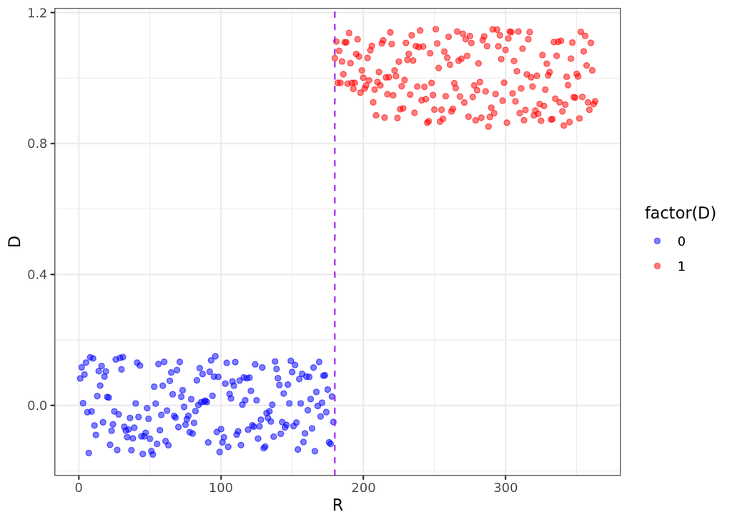

```r
theme_set(theme_bw(base_family = "HiraKakuProN-W3"))

ggplot(data = df1,
       mapping = aes(x = R,
                     y = D,
                     color = factor(D))
       ) +
  geom_point(alpha = 0.5,
             alpha = 0.5,
             position = position_jitter(width = 0, height = 0.15)) +
  geom_vline(xintercept = 180,
             color = "purple",
             linetype = 2) +
  scale_color_manual(values = c("blue", "red"))
```

また，上図のような境界を記述的な数値で実際に確認すると，

```r
df1 |>
  group_by(D, R < 60) |>
  summarize(count = n())
```

```
# A tibble: 3 × 3
# Groups:   D [2]
      D `R < 60` count
  <dbl> <lgl>    <int>
1     0 FALSE      120
2     0 TRUE        59
3     1 FALSE      184
```

ゆえに，オーバーラップする試合が存在しないため，RDDの手法をこのデータに用いるにおいては，sharpの論理が適切であることがわかる。また，fuzzy論理は情報理論を中心に用いられることが多く，「真の度合い」を測定し，同じ実世界の事象に異なるモデルを提供する。すなわち，「ピッチクロック制度の導入は真か」という別の仮定ならば，fuzzy論理が適切である可能性もある点に留意されたい。

また，カットオフ（上図の散布図における境界線）によって処置の値が変わらないと仮定した場合，結果変数の値が非連続的なjumpをしないことを確認する。ここで，c=180の散布図とRDプロットを示す。

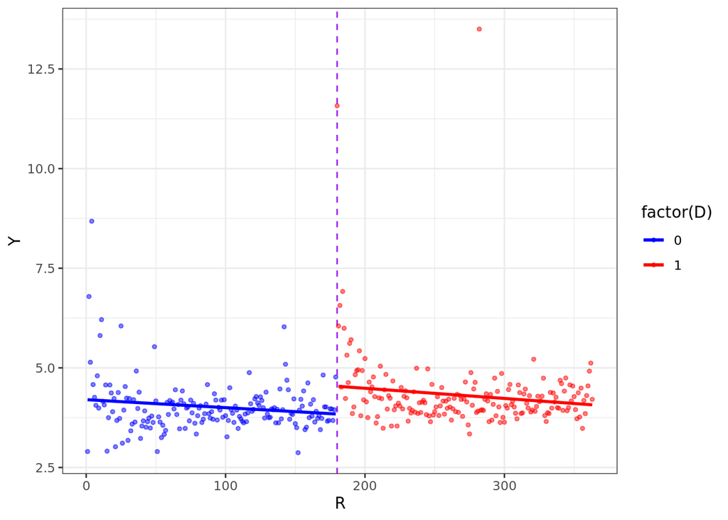

```r
ggplot(df1, aes(x = R, y = Y, color = factor(D)))+
  geom_vline(xintercept = 180, color = "purple", linetype = 2) +
  geom_point(size = 1, alpha = 0.5) +
  geom_smooth(data = filter(df1, R <= 180), method = "lm", se = FALSE) +
  geom_smooth(data = filter(df1, R > 180), method = "lm", se = FALSE) +
  scale_color_manual(values = c("blue", "red"))
```

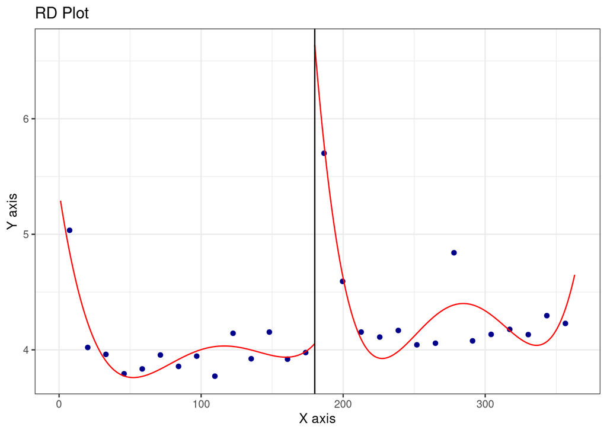

```r
rdplot(df1$Y, df1$R, c = 180)
```

上述の2グラフから推察できる通り，割当変数Rのカットオフ付近ではjumpが観測できたため，ピッチクロックの処置効果が期待できる。次に，カットオフであるc=180から値を30ポイントずらしたc=150の場合とc=210の場合を確認する。

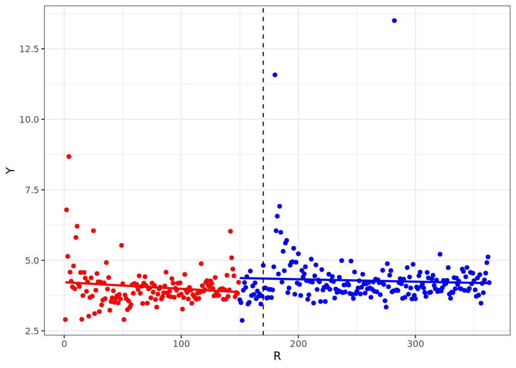

```r
#散布図(c=150)
df1 |>
  mutate(threshold = as.factor(ifelse(R < 150, 1, 0))) |>
  ggplot(aes(x = R, y = Y, color = threshold)) +
  geom_point() +
  geom_smooth(method = "lm", se = FALSE) +
  guides(color = FALSE) +
  geom_vline(xintercept = 170, color = "black", linetype = 2)+
  scale_color_manual(values = c("blue", "red"))
```

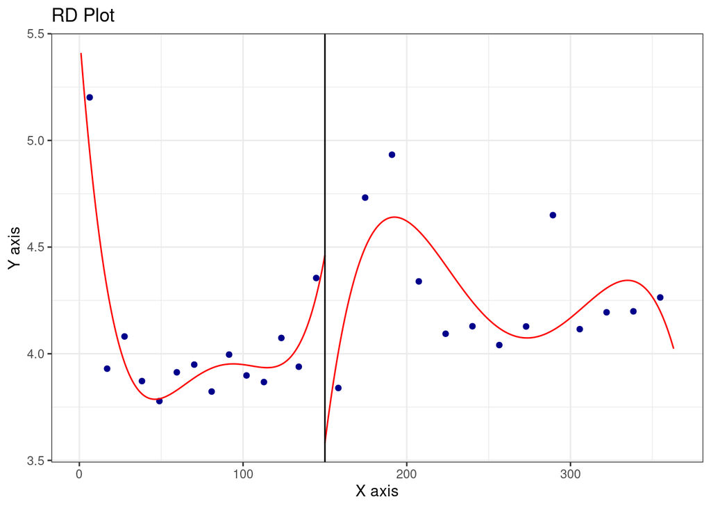

```r
#RDプロット(c=150)
rdplot(df1$Y, df1$R, c = 150)
```

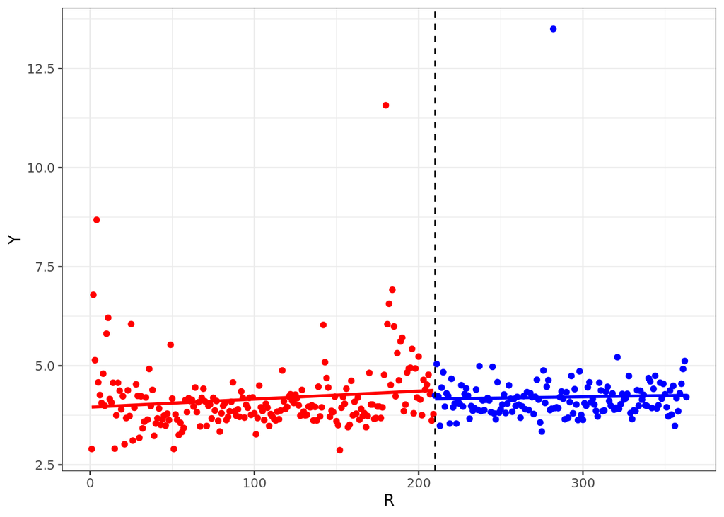

```r
#散布図(c=210)
df1 |>
  mutate(threshold = as.factor(ifelse(R < 210, 1, 0))) |>
  ggplot(aes(x = R, y = Y, color = threshold)) +
  geom_point() +
  geom_smooth(method = "lm", se = FALSE) +
  guides(color = FALSE) +
  geom_vline(xintercept = 210, color = "black", linetype = 2)+
  scale_color_manual(values = c("blue", "red"))
```

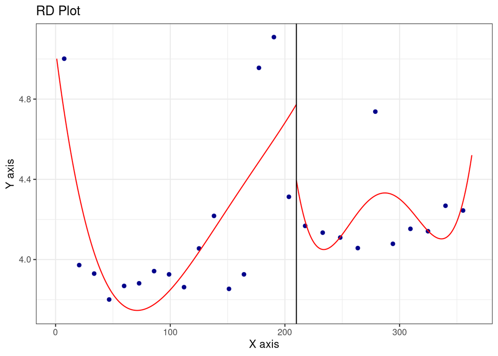

```r
#RDプロット(c=210)
rdplot(df1$Y, df1$R, c = 210)
```

### モデル

RDDはDiD（Difference in Differences）よりも強い仮定を置かなければならない手法ではあるが，前章で述べた通り，それらについて妥当な仮定がおかれていることが確認できた。次に推定値を求めるわけであるが，今回のデータでは，防御率という正しい関数形を特定することが難しい値を基にしている（例えば，レストランの人気度のような順序的な統計量と同様）ため，ノンパラメトリック手法のRDで推定値を求める。推定では，IK（バンド幅）、CER （最適バンド幅）という複数のバンド幅を用いたモデリングの結果の平均値を処置効果とする。まず，記述的な値を反映させる。

```r
IKband <- rdbwselect_2014(df1$Y,
                          df1$R,
                          c = 180,
                          bwselect = "IK")
IKband$bws
```

```
            h       b
[1,] 51.83051 67.5932
```

```r
model_IK <- rdrobust(df1$Y,
                     df1$R,
                     c = 180,
                     h = IKband$bws[1,1],
                     kernel = "triangular",
                     all = TRUE)
summary(model_IK)
```

```
Sharp RD estimates using local polynomial regression.

Number of Obs.                  363
BW type                      Manual
Kernel                   Triangular
VCE method                       NN

Number of Obs.                  179          184
Eff. Number of Obs.              51           52
Order est. (p)                    1            1
Order bias  (q)                   2            2
BW est. (h)                  51.831       51.831
BW bias (b)                  51.831       51.831
rho (h/b)                     1.000        1.000
Unique Obs.                     179          184

=============================================================================
        Method     Coef. Std. Err.         z     P>|z|      [ 95% C.I. ]
=============================================================================
  Conventional     2.289     0.640     3.577     0.000     [1.035 , 3.544]
Bias-Corrected     3.075     0.640     4.805     0.000     [1.821 , 4.329]
        Robust     3.075     1.153     2.666     0.008     [0.814 , 5.335]
=============================================================================
```

このように，IKによって推奨されたバンド幅（51.831）の時の「ピッチクロック導入による防御率の差」推定値は2.289である。続いて，CERを用いたモデリングを検証する。

```r
model_cer <- rdrobust(df1$Y,
                      df1$R,
                      c = 180,
                      bwselect = "cerrd",
                      all = TRUE)
summary(model_cer)
```

```
Sharp RD estimates using local polynomial regression.

Number of Obs.                  363
BW type                       cerrd
Kernel                   Triangular
VCE method                       NN

Number of Obs.                  179          184
Eff. Number of Obs.              25           26
Order est. (p)                    1            1
Order bias  (q)                   2            2
BW est. (h)                  25.923       25.923
BW bias (b)                  65.190       65.190
rho (h/b)                     0.398        0.398
Unique Obs.                     179          184

=============================================================================
        Method     Coef. Std. Err.         z     P>|z|      [ 95% C.I. ]
=============================================================================
  Conventional     3.048     1.150     2.651     0.008     [0.794 , 5.302]
Bias-Corrected     3.168     1.150     2.755     0.006     [0.914 , 5.422]
        Robust     3.168     1.215     2.607     0.009     [0.786 , 5.550]
=============================================================================
```

上図より，CERによって推奨されたバンド幅（25.923）の時の「ピッチクロック導入による防御率の差」推定値は3.048である。これらの分析結果から得られたIK、CER、CERバイアス修正、CERロバストの平均を計算すると，以下の値が得られる。

```r
(2.289+3.048+3.168+3.168)/4
```

```
[1] 2.91825
```

よって，ピッチクロック導入によって，投手の防御率が2.92（小数第3位四捨五入）上昇することが分かった。防御率の上昇は投手にとっては選手生命を左右する出来事であり，本論文で提示した仮定「ピッチクロック制度は，投手の防御率を悪化させる」が正しい可能性があることが実証された。

### 参考文献

- Albert, J. Bennett, J. (2003). Curve Ball: Baseball, Statistics, and the Role of Chance in the Game. Repr. 2003 Edition. Springer-Verlag New York, LLC.
- Anthony, Castrovine (2018). Players chime in on pace-of-play discussion: Pace of play has improved in Minors, but opinion is divided at Major League level. MLB.
- Steven, Goldman (2005). Mind Game: How the Boston Red Sox Got Smart, Won a World Series, and Created a New Blueprint for Winning. New York City: Workman Publishing Company.
- Bill, James (2001). The New Bill James Historical Baseball Abstract.
- 鳥越規央（2014）.『勝てる野球の統計学』岩波書店.